# Capstone - VAR Optimization

Author

Brandon Dahl

## Hedging Strategy

After creating our forecasts of possible exchange rate paths using Geometric Brownian Motion for the six currencies to which Regeneron is exposed, the next phase of our analysis is to devise a hedging strategy.

There are various aims targets a company could focus in deriving a foreign exchange hedging strategy, from reducing volatility in earnings to reducing maximum possible losses. Regardless of the specific measure a company takes, all of it will revolve around reducing risk to the company.

For our analysis, the focus of our optimization will be on a common risk metric in finance, Value-At-Risk or VAR.

VAR is a statistical measure that gives an estimate of potential losses over a specified time period with a given confidence level. An accurate measure of VAR is key to understanding the riskiness of a portfolio.

While a company manufacturing a product may not seem like an investment portfolio per se, it’s most instructive in grasping foreign exchange risk to think of all international revenue as revenue that is forcibly invested in an asset that will yield a certain return. And that return will be the difference in exchange rates that arise between when the revenue is earned in the foreign currency, and when it’s converted back to the domestic currency. As such, VAR is a useful metric for measuring and optimizing foreign exchange risk.

## Hedging Optimization

Given that VAR is a useful metric for foreign exchange risk, the aim of our optimization will be to minimize the cost of hedging across N simulations while targeting a pre-specified VAR.

### Assumptions

1. International cash flows are converted at mean exchange rate during the year
2. Hedged revenue is sum of hedged and non-hedged cash minus hedge cost
3. VAR is measured at 5% quantile of losses against baseline portfolio across all simulations
4. Hedging cost is assumed to be .1% of notional amount

## Setup Optimization & Data Functions

### Configure Cash Flows

```r
# Create Optimization Dataset
opt_df <- cash_flow_setup |>
  # Filter Columns
  select(-c(contains('rev_current_daily_sim'),
            rev_total_current,
            rev_total_current_sim))  |>
  # Add Optimized Columns
  mutate(opt_hedge_ratio_aud = NA_real_,
         opt_hedge_ratio_cad = NA_real_,
         opt_hedge_ratio_cny = NA_real_,
         opt_hedge_ratio_eur = NA_real_,
         opt_hedge_ratio_gbp = NA_real_,
         opt_hedge_ratio_jpy = NA_real_,
         # Hedged Cash
         opt_hedged_cash_aud = NA_real_,
         opt_hedged_cash_cad = NA_real_,
         opt_hedged_cash_cny = NA_real_,
         opt_hedged_cash_eur = NA_real_,
         opt_hedged_cash_gbp = NA_real_,
         opt_hedged_cash_jpy = NA_real_,
         # Non-Hedged Cash
         opt_non_hedged_cash_aud = NA_real_,
         opt_non_hedged_cash_cad = NA_real_,
         opt_non_hedged_cash_cny = NA_real_,
         opt_non_hedged_cash_eur = NA_real_,
         opt_non_hedged_cash_gbp = NA_real_,
         opt_non_hedged_cash_jpy = NA_real_,
         # Hedge Cost
         opt_hedge_cost_aud = NA_real_,
         opt_hedge_cost_cad = NA_real_,
         opt_hedge_cost_cny = NA_real_,
         opt_hedge_cost_eur = NA_real_,
         opt_hedge_cost_gbp = NA_real_,
         opt_hedge_cost_jpy = NA_real_,
         # Totals
         opt_total_cash_hedged = NA_real_,
         opt_total_cash_non_hedged = NA_real_,
         opt_total_hedge_cost = NA_real_,
         opt_total_cash = NA_real_) |>
  # Arrange
  arrange(sim, days)
```

## Setup Optimization Functions

### Hedging Function

```r
hedging_function <- function(aud_hedge_ratio, cad_hedge_ratio, cny_hedge_ratio, eur_hedge_ratio,
                             gbp_hedge_ratio, jpy_hedge_ratio, hedge_cost_pct){

  # Perform Hedging Calculation
  opt_df_hedged <- opt_df |>
    # Add In Hedge Ratio
    mutate(opt_hedge_ratio_aud = aud_hedge_ratio,
           opt_hedge_ratio_cad = cad_hedge_ratio,
           opt_hedge_ratio_cny = cny_hedge_ratio,
           opt_hedge_ratio_eur = eur_hedge_ratio,
           opt_hedge_ratio_gbp = gbp_hedge_ratio,
           opt_hedge_ratio_jpy = jpy_hedge_ratio) |>
    # Calculate Hedged Cash
    mutate(opt_hedged_cash_aud = (rev_current_daily_aud*opt_hedge_ratio_aud*exchange_rate_current_aud)/exchange_rate_current_aud,
           opt_hedged_cash_cad = (rev_current_daily_cad*opt_hedge_ratio_cad*exchange_rate_current_cad)/exchange_rate_current_cad,
           opt_hedged_cash_cny = (rev_current_daily_cny*opt_hedge_ratio_cny*exchange_rate_current_cny)/exchange_rate_current_cny,
           opt_hedged_cash_eur = (rev_current_daily_eur*opt_hedge_ratio_eur*exchange_rate_current_eur)/exchange_rate_current_eur,
           opt_hedged_cash_gbp = (rev_current_daily_gbp*opt_hedge_ratio_gbp*exchange_rate_current_gbp)/exchange_rate_current_gbp,
           opt_hedged_cash_jpy = (rev_current_daily_jpy*opt_hedge_ratio_jpy*exchange_rate_current_jpy)/exchange_rate_current_jpy) |>
    # Calculate Non-Hedged Cash
    group_by(sim) |>
    mutate(opt_non_hedged_cash_aud = (rev_current_daily_aud*(1 - opt_hedge_ratio_aud)*exchange_rate_current_aud)/mean(simulated_rate_aud),
           opt_non_hedged_cash_cad = (rev_current_daily_cad*(1 - opt_hedge_ratio_cad)*exchange_rate_current_cad)/mean(simulated_rate_cad),
           opt_non_hedged_cash_cny = (rev_current_daily_cny*(1 - opt_hedge_ratio_cny)*exchange_rate_current_cny)/mean(simulated_rate_cny),
           opt_non_hedged_cash_eur = (rev_current_daily_eur*(1 - opt_hedge_ratio_eur)*exchange_rate_current_eur)/mean(simulated_rate_eur),
           opt_non_hedged_cash_gbp = (rev_current_daily_gbp*(1 - opt_hedge_ratio_gbp)*exchange_rate_current_gbp)/mean(simulated_rate_gbp),
           opt_non_hedged_cash_jpy = (rev_current_daily_jpy*(1 - opt_hedge_ratio_jpy)*exchange_rate_current_jpy)/mean(simulated_rate_jpy)) |>
    ungroup() |>
    # Calculate Hedge Cost
    mutate(opt_hedge_cost_aud = rev_current_daily_aud*opt_hedge_ratio_aud*hedge_cost_pct,
           opt_hedge_cost_cad = rev_current_daily_cad*opt_hedge_ratio_cad*hedge_cost_pct,
           opt_hedge_cost_cny = rev_current_daily_cny*opt_hedge_ratio_cny*hedge_cost_pct,
           opt_hedge_cost_eur = rev_current_daily_eur*opt_hedge_ratio_eur*hedge_cost_pct,
           opt_hedge_cost_gbp = rev_current_daily_gbp*opt_hedge_ratio_gbp*hedge_cost_pct,
           opt_hedge_cost_jpy = rev_current_daily_jpy*opt_hedge_ratio_jpy*hedge_cost_pct) |>
    # Calculate Currency Totals
    mutate(opt_total_cash_aud = opt_hedged_cash_aud + opt_non_hedged_cash_aud,
           opt_total_cash_cad = opt_hedged_cash_cad + opt_non_hedged_cash_cad,
           opt_total_cash_cny = opt_hedged_cash_cny + opt_non_hedged_cash_cny,
           opt_total_cash_eur = opt_hedged_cash_eur + opt_non_hedged_cash_eur,
           opt_total_cash_gbp = opt_hedged_cash_gbp + opt_non_hedged_cash_gbp,
           opt_total_cash_jpy = opt_hedged_cash_jpy + opt_non_hedged_cash_jpy) |>
    # Calculate Total Revenue
    mutate(opt_total_revenue_aud = opt_total_cash_aud - opt_hedge_cost_aud,
           opt_total_revenue_cad = opt_total_cash_cad - opt_hedge_cost_cad,
           opt_total_revenue_cny = opt_total_cash_cny - opt_hedge_cost_cny,
           opt_total_revenue_eur = opt_total_cash_eur - opt_hedge_cost_eur,
           opt_total_revenue_gbp = opt_total_cash_gbp - opt_hedge_cost_gbp,
           opt_total_revenue_jpy = opt_total_cash_jpy - opt_hedge_cost_jpy) |>
    # Calculate Totals
    mutate(opt_total_cash_baseline = rowSums(across(starts_with('rev_current_daily_')), na.rm = TRUE),
           opt_total_cash_hedged = rowSums(across(starts_with('opt_hedged_cash_')), na.rm = TRUE),
           opt_total_cash_non_hedged = rowSums(across(starts_with('opt_non_hedged_cash_')), na.rm = TRUE),
           opt_total_hedge_cost = rowSums(across(starts_with('opt_hedge_cost_')), na.rm = TRUE),
           opt_total_cash = rowSums(across(starts_with('opt_total_cash_')), na.rm = TRUE),
           opt_total_revenue = rowSums(across(starts_with('opt_total_revenue')), na.rm = TRUE),
           opt_total_cash_gain_loss = opt_total_revenue - opt_total_cash_baseline,
           opt_total_cash_gain_loss_pct = opt_total_cash_gain_loss/opt_total_cash_baseline) |>
    ungroup() |>
    # Order Data
    arrange(sim, days)

  # Create Comprehensive Simulation Summary
  opt_df_hedged_summary <- opt_df_hedged |>
    group_by(sim) |>
    # Simulated Exchange Rates
    summarise(simulated_rate_aud = mean(simulated_rate_aud, na.rm = TRUE),
              simulated_rate_cad = mean(simulated_rate_cad, na.rm = TRUE),
              simulated_rate_cny = mean(simulated_rate_cny, na.rm = TRUE),
              simulated_rate_eur = mean(simulated_rate_eur, na.rm = TRUE),
              simulated_rate_gbp = mean(simulated_rate_gbp, na.rm = TRUE),
              simulated_rate_jpy = mean(simulated_rate_jpy, na.rm = TRUE),
              # Current Exchange Rates
              exchange_rate_current_aud = mean(exchange_rate_current_aud, na.rm = TRUE),
              exchange_rate_current_cad = mean(exchange_rate_current_cad, na.rm = TRUE),
              exchange_rate_current_cny = mean(exchange_rate_current_cny, na.rm = TRUE),
              exchange_rate_current_eur = mean(exchange_rate_current_eur, na.rm = TRUE),
              exchange_rate_current_gbp = mean(exchange_rate_current_gbp, na.rm = TRUE),
              exchange_rate_current_jpy = mean(exchange_rate_current_jpy, na.rm = TRUE),
              # Rev Percent
              rev_pct_aud = mean(rev_pct_aud, na.rm = TRUE),
              rev_pct_cad = mean(rev_pct_cad, na.rm = TRUE),
              rev_pct_cny = mean(rev_pct_cny, na.rm = TRUE),
              rev_pct_eur = mean(rev_pct_eur, na.rm = TRUE),
              rev_pct_gbp = mean(rev_pct_gbp, na.rm = TRUE),
              rev_pct_jpy = mean(rev_pct_jpy, na.rm = TRUE),
              # Optimized Hedge Ratios
              opt_hedge_ratio_aud = mean(opt_hedge_ratio_aud, na.rm = TRUE),
              opt_hedge_ratio_cad = mean(opt_hedge_ratio_cad, na.rm = TRUE),
              opt_hedge_ratio_cny = mean(opt_hedge_ratio_cny, na.rm = TRUE),
              opt_hedge_ratio_eur = mean(opt_hedge_ratio_eur, na.rm = TRUE),
              opt_hedge_ratio_gbp = mean(opt_hedge_ratio_gbp, na.rm = TRUE),
              opt_hedge_ratio_jpy = mean(opt_hedge_ratio_jpy, na.rm = TRUE),
              # Optimized Hedge Cash
              opt_hedged_cash_aud = sum(opt_hedged_cash_aud, na.rm = TRUE),
              opt_hedged_cash_cad = sum(opt_hedged_cash_cad, na.rm = TRUE),
              opt_hedged_cash_cny = sum(opt_hedged_cash_cny, na.rm = TRUE),
              opt_hedged_cash_eur = sum(opt_hedged_cash_eur, na.rm = TRUE),
              opt_hedged_cash_gbp = sum(opt_hedged_cash_gbp, na.rm = TRUE),
              opt_hedged_cash_jpy = sum(opt_hedged_cash_jpy, na.rm = TRUE),
              # Optimized Non-Hedged Cash
              opt_non_hedged_cash_aud = sum(opt_non_hedged_cash_aud, na.rm = TRUE),
              opt_non_hedged_cash_cad = sum(opt_non_hedged_cash_cad, na.rm = TRUE),
              opt_non_hedged_cash_cny = sum(opt_non_hedged_cash_cny, na.rm = TRUE),
              opt_non_hedged_cash_eur = sum(opt_non_hedged_cash_eur, na.rm = TRUE),
              opt_non_hedged_cash_gbp = sum(opt_non_hedged_cash_gbp, na.rm = TRUE),
              opt_non_hedged_cash_jpy = sum(opt_non_hedged_cash_jpy, na.rm = TRUE),
              # Optimized Hedge Cost
              opt_hedge_cost_aud = sum(opt_hedge_cost_aud, na.rm = TRUE),
              opt_hedge_cost_cad = sum(opt_hedge_cost_cad, na.rm = TRUE),
              opt_hedge_cost_cny = sum(opt_hedge_cost_cny, na.rm = TRUE),
              opt_hedge_cost_eur = sum(opt_hedge_cost_eur, na.rm = TRUE),
              opt_hedge_cost_gbp = sum(opt_hedge_cost_gbp, na.rm = TRUE),
              opt_hedge_cost_jpy = sum(opt_hedge_cost_jpy, na.rm = TRUE),
              # Optimized Total Cash
              opt_total_cash_aud = sum(opt_total_cash_aud, na.rm = TRUE),
              opt_total_cash_cad = sum(opt_total_cash_cad, na.rm = TRUE),
              opt_total_cash_cny = sum(opt_total_cash_cny, na.rm = TRUE),
              opt_total_cash_eur = sum(opt_total_cash_eur, na.rm = TRUE),
              opt_total_cash_gbp = sum(opt_total_cash_gbp, na.rm = TRUE),
              opt_total_cash_jpy = sum(opt_total_cash_jpy, na.rm = TRUE),
              # optimized Total Revenue
              opt_total_revenue_aud = sum(opt_total_revenue_aud, na.rm = TRUE),
              opt_total_revenue_cad = sum(opt_total_revenue_cad, na.rm = TRUE),
              opt_total_revenue_cny = sum(opt_total_revenue_cny, na.rm = TRUE),
              opt_total_revenue_eur = sum(opt_total_revenue_eur, na.rm = TRUE),
              opt_total_revenue_gbp = sum(opt_total_revenue_gbp, na.rm = TRUE),
              opt_total_revenue_jpy = sum(opt_total_revenue_jpy, na.rm = TRUE),
              # Calculate Totals
              opt_total_hedge_cost = sum(opt_total_hedge_cost, na.rm = TRUE),
              opt_total_cash_baseline = sum(opt_total_cash_baseline, na.rm = TRUE),
              opt_total_revenue = sum(opt_total_revenue, na.rm = TRUE)) |>
    ungroup() |>
    mutate(opt_total_cash_gain_loss = opt_total_revenue - opt_total_cash_baseline,
           opt_total_cash_gain_loss_pct = opt_total_cash_gain_loss/opt_total_cash_baseline)

  # Monte Carlo Summary
  opt_df_hedged_mc_summary <- opt_df_hedged_summary |>
    summarise(opt_total_hedge_cost_mean = mean(opt_total_hedge_cost, na.rm = TRUE),
              opt_total_cash_baseline_mean = mean(opt_total_cash_baseline, na.rm = TRUE),
              opt_total_revenue_mean = mean(opt_total_revenue, na.rm = TRUE),
              opt_total_cash_gain_loss_mean = opt_total_revenue_mean - opt_total_cash_baseline_mean,
              opt_total_var = quantile(opt_total_cash_gain_loss, probs = .05),
              opt_total_var_pct = opt_total_var/opt_total_revenue_mean)

  # Return List
  return(list(opt_df_hedged = opt_df_hedged,
              opt_df_hedged_summary = opt_df_hedged_summary,
              opt_df_hedged_mc_summary = opt_df_hedged_mc_summary))

}
```

## Run Optimization

To increase the likelihood of finding an optimal portfolio for each given target VAR, constraints were placed on the minimum hedge percentages allowed for each target.

### Set Optimization Parameters

```r
# Set Optimal Hedge Cost
opt_hedge_cost_pct <- .001

# Set Target Var
target_var_ratio <- c(.05, .04, .03, .02, .01)

# Set Min Hedging
min_hedge_pcts <- c(0, .05, .1, .25, .5)
```

### Perform Brute Force Optimization

```r
# # Create Optimized Simulations
# optimized_sims <- data.frame()
#
# # Loop Through Vars
# for (v in 1:length(target_var_ratio)){
#
#   # Set Temp Target Var
#   temp.target.var <- target_var_ratio[v]
#
#   # Get Target VAR
#   target_var <- (hedging_function(aud_hedge_ratio = 0,
#                                   cad_hedge_ratio = 0,
#                                   cny_hedge_ratio = 0,
#                                   eur_hedge_ratio = 0,
#                                   gbp_hedge_ratio = 0,
#                                   jpy_hedge_ratio = 0,
#                                   hedge_cost_pct = 0) |>
#                    purrr::simplify() |>
#                    dplyr::last() |>
#                    pull(opt_total_cash_baseline_mean))*temp.target.var
#
#   # Setup Simulations
#   total_sims <- 1000
#
#   # Optimized Sims Count
#   optim_sim_cnt <- 0
#
#   # Notify user
#   paste0('Performing Optimization For Target Var: ', temp.target.var) |> print()
#
#   # Perform Simulation
#   for (s in 1:total_sims){
#
#     # Get Random
#     temp.rand.aud <- runif(n = 1, min = min_hedge_pcts[v], max = .95)
#     temp.rand.cad <- runif(n = 1, min = min_hedge_pcts[v], max = .95)
#     temp.rand.cny <- runif(n = 1, min = min_hedge_pcts[v], max = .95)
#     temp.rand.eur <- runif(n = 1, min = min_hedge_pcts[v], max = .95)
#     temp.rand.gbp <- runif(n = 1, min = min_hedge_pcts[v], max = .95)
#     temp.rand.jpy <- runif(n = 1, min = min_hedge_pcts[v], max = .95)
#
#     # Run Function
#     temp.hedge <- hedging_function(aud_hedge_ratio = temp.rand.aud,
#                                    cad_hedge_ratio = temp.rand.cad,
#                                    cny_hedge_ratio = temp.rand.cny,
#                                    eur_hedge_ratio = temp.rand.eur,
#                                    gbp_hedge_ratio = temp.rand.gbp,
#                                    jpy_hedge_ratio = temp.rand.jpy,
#                                    hedge_cost_pct = opt_hedge_cost_pct)
#
#     # Get Temp Var
#     temp.var <- temp.hedge$opt_df_hedged_mc_summary$opt_total_var
#
#     # Check
#     if (all(abs(temp.var) <= (target_var + 1),
#             abs(temp.var) >= (target_var - 1))){
#
#       # Increase Counter
#       optim_sim_cnt <- optim_sim_cnt + 1
#
#       # Notify user
#       paste0('    ',optim_sim_cnt,' Optimized Portfolios Found') |> print()
#
#       # Test
#       temp.optimized <- data.frame(target_var = temp.target.var,
#                                    aud_hedge_ratio = temp.rand.aud,
#                                    cad_hedge_ratio = temp.rand.cad,
#                                    cny_hedge_ratio = temp.rand.cny,
#                                    eur_hedge_ratio = temp.rand.eur,
#                                    gbp_hedge_ratio = temp.rand.gbp,
#                                    jpy_hedge_ratio = temp.rand.jpy,
#                                    opt_total_hedge_cost_mean = temp.hedge$opt_df_hedged_mc_summary$opt_total_hedge_cost_mean,
#                                    opt_total_cash_baseline_mean = temp.hedge$opt_df_hedged_mc_summary$opt_total_cash_baseline_mean,
#                                    opt_total_revenue_mean = temp.hedge$opt_df_hedged_mc_summary$opt_total_revenue_mean,
#                                    opt_total_cash_gain_loss_mean = temp.hedge$opt_df_hedged_mc_summary$opt_total_cash_gain_loss_mean,
#                                    opt_total_var = temp.hedge$opt_df_hedged_mc_summary$opt_total_var)
#
#       # Save Optimized Portfolios
#       optimized_sims <- rbind(optimized_sims,
#                               temp.optimized) |>
#         arrange(opt_total_hedge_cost_mean)
#
#     }
#
#   }
#
# }
```

### Extract Optimal Portfolio For Each Target VAR

```r
# Compute Best Portfolio
optimized_sims_clean <- optimized_sims |>
  group_by(target_var) |>
  arrange(opt_total_hedge_cost_mean) |>
  slice(1L) |>
  ungroup()

# Get Average Portfolio
optimized_sims_clean_avg <- optimized_sims |>
  group_by(target_var) |>
  # Calculate Statistics
  summarise(sims = dplyr::n(),
            aud_hedge_ratio = mean(aud_hedge_ratio, na.rm = TRUE),
            cad_hedge_ratio = mean(cad_hedge_ratio, na.rm = TRUE),
            cny_hedge_ratio = mean(cny_hedge_ratio, na.rm = TRUE),
            eur_hedge_ratio = mean(eur_hedge_ratio, na.rm = TRUE),
            gbp_hedge_ratio = mean(gbp_hedge_ratio, na.rm = TRUE),
            jpy_hedge_ratio = mean(jpy_hedge_ratio, na.rm = TRUE),
            opt_total_hedge_cost_mean = mean(opt_total_hedge_cost_mean, na.rm = TRUE),
            opt_total_cash_baseline_mean = mean(opt_total_cash_baseline_mean, na.rm = TRUE),
            opt_total_revenue_mean = mean(opt_total_revenue_mean, na.rm = TRUE),
            opt_total_cash_gain_loss_mean = mean(opt_total_cash_gain_loss_mean, na.rm = TRUE),
            opt_total_var = mean(opt_total_var, na.rm = TRUE)) |>
  ungroup()
```

### Optimal Hedging

Below you can see optimized hedging results for each VAR 95% target in the optimization:

- 1% of Baseline Revenue VAR
- 2% of baseline revenue VAR
- 3% of baseline revenue VAR
- 4% of baseline revenue VAR
- 5% of baseline revenue VAR

Optimized Hedging Strategy

| Target VAR Pct | Optimized Hedge Ratios AUD Hedge Ratio | Optimized Hedge Ratios CAD Hedge Ratio | Optimized Hedge Ratios CNY Hedge Ratio | Optimized Hedge Ratios EUR Hedge Ratio | Optimized Hedge Ratios GBP Hedge Ratio | Optimized Hedge Ratios JPY Hedge Ratio | Baseline Scenario Basline Revenue | Baseline Scenario Baseline Revenue Unhedged | Baseline Scenario Baseline VAR | Optimized Hedge Performance Hedge Cost Mean | Optimized Hedge Performance Hedged Revenue Mean | Optimized Hedge Performance Gain/Loss vs. Baseline | Optimized Hedge Performance Var 95% | Optimized Hedge Performance VAR 95% Pct | Optimized Hedge Performance VAR Reduction Pct |
| --- | --- | --- | --- | --- | --- | --- | --- | --- | --- | --- | --- | --- | --- | --- | --- |
| 0.01 | 87.9% | 75.6% | 70.2% | 90.9% | 88.4% | 52.3% | $6,456 | $6,424 | −$425 | $5 | $6,444 | −$12 | −$65 | 1.0% | 85% |
| 0.02 | 83.9% | 25.2% | 27.1% | 72.3% | 85.2% | 25.8% | $6,456 | $6,424 | −$425 | $4 | $6,440 | −$16 | −$130 | 2.0% | 69% |
| 0.03 | 53.5% | 48.7% | 15.2% | 46.5% | 76.9% | 37.5% | $6,456 | $6,424 | −$425 | $3 | $6,440 | −$16 | −$194 | 3.0% | 54% |
| 0.04 | 30.5% | 62.8% | 32.7% | 8.4% | 82.8% | 35.0% | $6,456 | $6,424 | −$425 | $2 | $6,448 | −$8 | −$259 | 4.0% | 39% |
| 0.05 | 94.9% | 10.0% | 22.5% | 3.6% | 16.5% | 24.9% | $6,456 | $6,424 | −$425 | $1 | $6,440 | −$16 | −$322 | 5.0% | 24% |

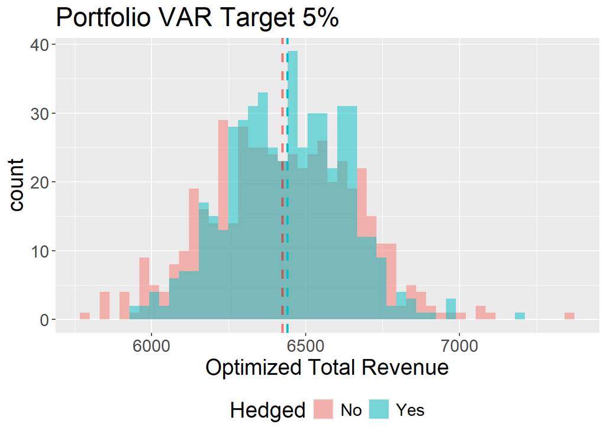

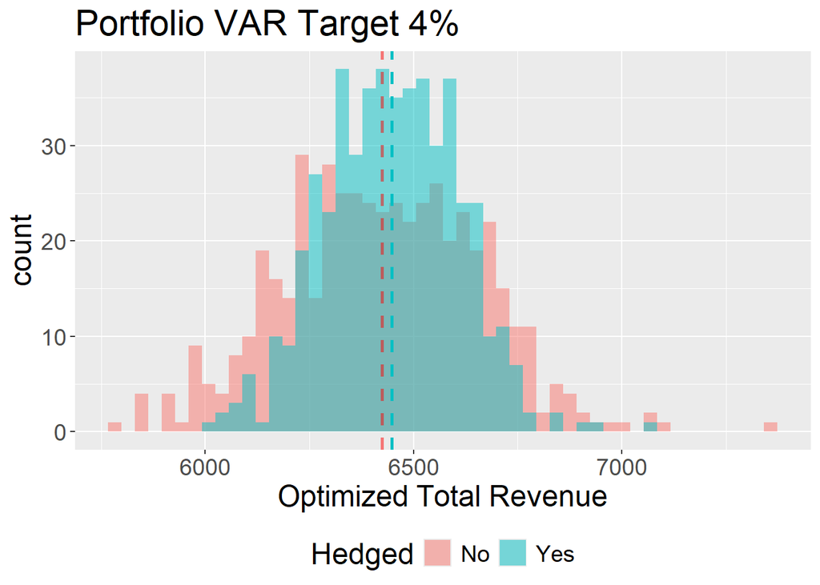

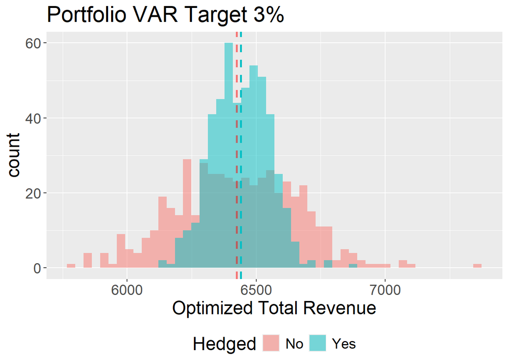

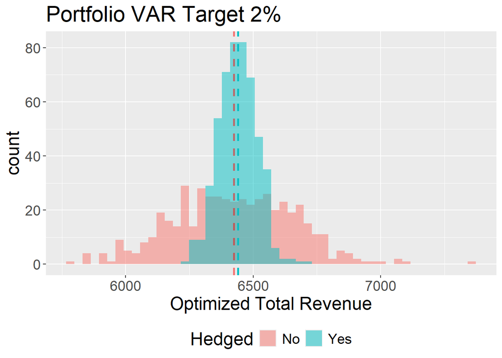

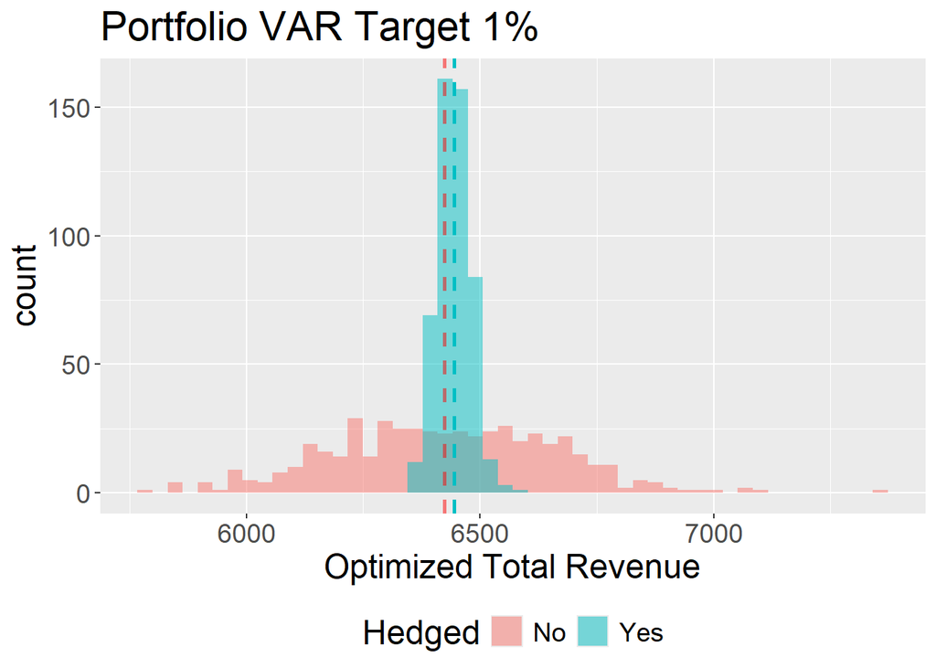

### Hedging Sensitivity

While finding the most optimal hedging portfolio for a target VAR is an important find in the optimization process, perhaps the most instructive finding is rather the sensitivity of the portfolio to increases in hedging dollars.

Understanding the sensitivity of the VAR to dollars invested in hedging is what allows the company to measure the usefulness of it’s hedging strategy, and ascertain the effectiveness of invested hedge dollars.

#### Regression Analysis

The regression formula is shown below:

$\text{ValueAtRisk}_i = \beta_0 + \beta_1 \cdot \text{MeanDollarHedgingCost}_i + \varepsilon_i$

```r
# Calculate Regression
hedge_regression <- optimized_sims |>
  lm(formula = opt_total_var ~ opt_total_hedge_cost_mean, data = _)
```

##### Regression Scatter Plot

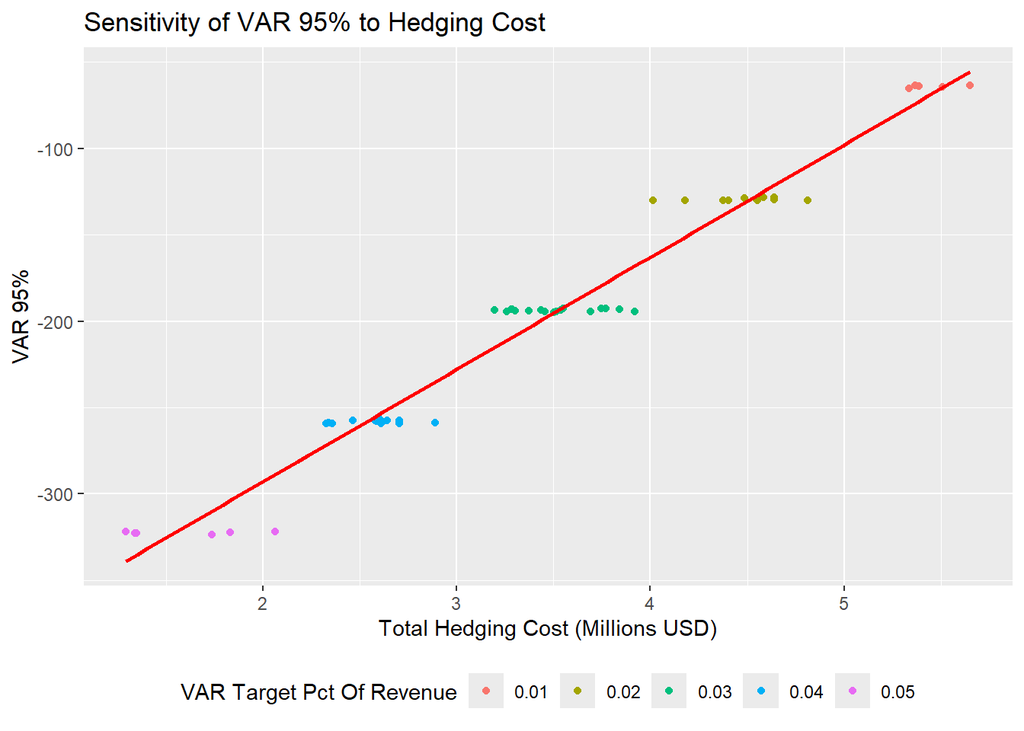

##### Regression Results

Regression Results

| term | estimate | std.error | statistic | p.value |
| --- | --- | --- | --- | --- |
| (Intercept) | -422.73 | 6.01 | -70.34 | 0 |
| Opt Total Hedge Cost | 64.96 | 1.66 | 39.19 | 0 |

Regression Accuracy

| r.squared | adj.r.squared | sigma | statistic | p.value |
| --- | --- | --- | --- | --- |
| 0.97 | 0.97 | 13.52 | 1536.05 | 0 |